# sparkify-edited-final-version

#### Basic Data type conversions:

In order to perform a good data visualization and later feature engineering, let's transform some of the current features we have into their ideal data types.

```python
from datetime import datetime
from pyspark.sql.functions import udf, col
from pyspark.sql.functions import max as sparkmax, min as sparkmin, to_timestamp
from pyspark.sql import functions as pyfun
from pyspark.sql.window import Window
from pyspark.sql import functions as F

# Apply mapping for churn criticality
churn_classes_criticality = {"Cancellation Confirmation": 1}

# Read Data
df = spark.sql("select * from medium_sparkify_event_data_9e3be_json")

# UDFs
criticalityMapper = udf(lambda page: churn_classes_criticality[page] if page in churn_classes_criticality.keys() else 0)
tsToDate = udf(lambda ts: datetime.fromtimestamp(ts/1000).strftime("%Y-%m-%d %H:%M:%S"))
levelMapper = udf(lambda lev: 1 if lev == "paid" else 0)
genderMapper = udf(lambda gen: 1 if gen == "M" else 0)

"""
Remove the logs that does contain userId's as null values
"""
df = df.where(df["userId"] != "").where(df["userId"].isNotNull())

"""
Transform columns
"""
df = df.withColumn("churn", criticalityMapper("page"))
df = df.withColumn("level", levelMapper("level"))
df = df.withColumn("gender", genderMapper("gender"))
df = df.withColumn("ts", tsToDate("ts"))
df = df.withColumn("userId", df["userId"].cast("integer"))
df = df.withColumn("sessionId", df["sessionId"].cast("integer"))
df = df.withColumn("length", df["length"].cast("float"))
```

```python
def getSongsPlayedByUser(dataFrameIn):
  """
  Function to retrieve the number of songs listened by each user
  """
  dataFrameOut = dataFrameIn.where(dataFrameIn["page"] == "NextSong").groupby("userId").agg({"page" : "count"}).withColumnRenamed("count(page)", "total_songs_played")
  return dataFrameOut

def getSecondsByUsers(dataFrameIn):
  """
  Function to retrieve the hours played by each user
  """
  dataFrameOut = dataFrameIn.groupby("userId").agg({"length" : "sum"}).withColumnRenamed("sum(length)", "total_seconds").withColumn("total_seconds", col("total_seconds").cast("integer"))
  return dataFrameOut

def getTotalSessionsByUser(dataFrameIn):
  """
  Function to retrieve the number of sessions initiated by each user
  """
  dataFrameOut = dataFrameIn.groupby("userId").agg(pyfun.countDistinct("sessionId")).withColumnRenamed("count(DISTINCT sessionId)", "total_sessions")
  return dataFrameOut

def getMeanHoursPerSession(dataFrameIn):
  """
  Function to retrieve the average hours per session consumed by each user
  """
  dataFrameOut = dataFrameIn.select("userId", "length", "sessionId").groupby(["userId", "sessionId"]).agg({"length": "sum"}).groupby("userId").agg({"sum(length)": "average"}).withColumnRenamed("avg(sum(length))", "avg_hours_per_session").withColumn("avg_hours_per_session", col("avg_hours_per_session").cast("integer"))
  return dataFrameOut

def getLevelChanges(dataFrameIn):
  """
  Function to retrieve the number of times a user changed their level
  """
  dataFrameOut = dataFrameIn.groupby("userId", "level").agg(pyfun.count("level").alias("nlevel")).withColumn("nzeros", pyfun.when(pyfun.col("level") == 0, pyfun.col("nlevel")).otherwise(0)).withColumn("nones", pyfun.when(pyfun.col("level") == 1, pyfun.col("nlevel")).otherwise(0)).select("userId", "nzeros", "nones").groupBy("userId").agg({"nzeros": "sum", "nones" : "sum"}).withColumnRenamed("sum(nzeros)", "n_free_items").withColumnRenamed("sum(nones)", "n_paid_items")
  return dataFrameOut

def getCountOfStages(dataFrameIn):
  """
  Function to retrieve the amount of times an user clicked on each of the events
  """
  dataFrameOut_0 = dataFrameIn.where(pyfun.col("page") == "Thumbs Down").groupby("userId").agg({"page" : "count"}).withColumnRenamed("count(page)", "n_thumbs_down")
  dataFrameOut_1 = dataFrameIn.where(pyfun.col("page") == "Thumbs Up").groupby("userId").agg({"page" : "count"}).withColumnRenamed("count(page)", "n_thumbs_up")
  dataFrameOut_2 = dataFrameIn.where(pyfun.col("page") == "Upgrade").groupby("userId").agg({"page" : "count"}).withColumnRenamed("count(page)", "n_upgrades")
  dataFrameOut_3 = dataFrameIn.where(pyfun.col("page") == "Help").groupby("userId").agg({"page" : "count"}).withColumnRenamed("count(page)", "n_helps")
  dataFrameOut = dataFrameOut_0.join(dataFrameOut_1, "userId").join(dataFrameOut_2, "userId").join(dataFrameOut_3, "userId")
  return dataFrameOut

def getChurnsByUser(dataFrameIn):
  """
  Function to calculate the cancellations confirmed by each user
  """
  dataFrameOut = dataFrameIn.groupBy("userId").agg({"churn": "sum"}).withColumnRenamed("sum(churn)", "total_churns")
  return dataFrameOut

def getTimeSpansFeatures(dataFrameIn):
  """
  Function to retrieve several time-related features such as the total time registered in the platform and the average time between initiated sessions.
  """

  # Get time from first use to last use
  dataFrameOut1 = dataFrameIn.groupby("userId").agg({"ts": "min"}).withColumnRenamed("min(ts)", "first_use_ts")
  dataFrameOut2 = dataFrameIn.groupby("userId").agg({"ts": "max"}).withColumnRenamed("max(ts)", "last_use_ts")
  dataFrameOut = dataFrameOut2.join(dataFrameOut1, "userId")
  dataFrameOut = dataFrameOut.withColumn("first_use_ts", pyfun.unix_timestamp(dataFrameOut.first_use_ts))
  dataFrameOut = dataFrameOut.withColumn("last_use_ts", pyfun.unix_timestamp(dataFrameOut.last_use_ts))
  dataFrameOut = dataFrameOut.withColumn("time_from_first_use_to_last", pyfun.col("last_use_ts") - pyfun.col("first_use_ts"))

  # Get average time between sessions
  dataFrameOut_ = dataFrameIn.groupby("sessionId", "userId").agg(pyfun.min("ts"), pyfun.max("ts")).sort("userid", "sessionId")
  dataFrameOut_ = dataFrameOut_.withColumn("session_duration", F.unix_timestamp(F.col("max(ts)")) - F.unix_timestamp(F.col("min(ts)")))
  window = Window.partitionBy().orderBy("userId", "sessionId")
  dataFrameOut_ = dataFrameOut_.withColumn("prev_min_ts", F.lag(F.col("min(ts)")).over(window))
  dataFrameOut_ = dataFrameOut_.withColumn("prev_user_id", F.lag(F.col("userId")).over(window))
  dataFrameOut_ = dataFrameOut_.withColumn("time_between_session",
                     F.when(F.col("prev_user_id") != "null", 0).when(F.col("prev_user_id") == F.col("userId"),
                            F.unix_timestamp(F.col("max(ts)")) - F.unix_timestamp(F.col("prev_min_ts"))).otherwise(0))
  dataFrameOut_ = dataFrameOut_.groupby("userId").agg({"time_between_session": "avg"}).withColumnRenamed("avg(time_between_session)", "avg_time_between_session").withColumn("avg_time_between_session", F.col("avg_time_between_session").cast("integer"))
  dataFrameOut_ = dataFrameOut_.withColumn("avg_time_between_session", F.col("avg_time_between_session")/86400)
  dataFrameOut_ = dataFrameOut_.withColumn("avg_time_between_session", F.round(F.col("avg_time_between_session"), 2))
  dataFrameOut_ = dataFrameOut_.withColumnRenamed("avg_time_between_session", "avg_days_between_session")
  dataFrameOutFinal = dataFrameOut.join(dataFrameOut_, "userId")
  return dataFrameOutFinal

"""
Apply all the functions to the dataset to produce every different dataframe that will be later joined together upon the userId.
"""
df_hoursByUser = getSecondsByUsers(df)
df_songsByUser = getSongsPlayedByUser(df)
df_sessionsByUser = getTotalSessionsByUser(df)
df_meanHoursPerSession = getMeanHoursPerSession(df)
df_levelChanges = getLevelChanges(df)
df_stagesCount = getCountOfStages(df)
df_withChurns = getChurnsByUser(df)
df_withTimeSpans = getTimeSpansFeatures(df)

dfFinal = df_hoursByUser.join(df_songsByUser, "userId").join(df_sessionsByUser, "userId").join(df_meanHoursPerSession, "userId").join(df_levelChanges, "userId").join(df_stagesCount, "userId").join(df_withChurns, "userId").join(df_withTimeSpans, "userId")

"""Transform the data type of each of the columns"""
dfFinal = dfFinal.withColumn("total_seconds", dfFinal["total_seconds"].cast("integer"))
dfFinal = dfFinal.withColumn("total_songs_played", dfFinal["total_songs_played"].cast("integer"))
dfFinal = dfFinal.withColumn("avg_hours_per_session", dfFinal["avg_hours_per_session"].cast("integer"))
dfFinal = dfFinal.withColumn("n_free_items", dfFinal["n_free_items"].cast("integer"))
dfFinal = dfFinal.withColumn("n_paid_items", dfFinal["n_paid_items"].cast("integer"))
dfFinal = dfFinal.withColumn("n_thumbs_down", dfFinal["n_thumbs_down"].cast("integer"))
dfFinal = dfFinal.withColumn("n_upgrades", dfFinal["n_upgrades"].cast("integer"))
dfFinal = dfFinal.withColumn("n_helps", dfFinal["n_helps"].cast("integer"))
dfFinal = dfFinal.withColumn("total_churns", dfFinal["total_churns"].cast("integer"))

# Normalize time-related features with the time registered within the platform
dfFinalTimeScaled = dfFinal.withColumn("time_from_first_use_to_last", dfFinal["time_from_first_use_to_last"]/3600) # Put time in hours
dfFinalTimeScaled = dfFinalTimeScaled.withColumn("total_seconds", dfFinalTimeScaled["total_seconds"]/(3600*dfFinalTimeScaled["time_from_first_use_to_last"]))
dfFinalTimeScaled = dfFinalTimeScaled.withColumn("avg_hours_per_session", dfFinalTimeScaled["avg_hours_per_session"]/(3600*dfFinalTimeScaled["total_sessions"]))
dfFinalTimeScaled = dfFinalTimeScaled.withColumn("n_free_items", dfFinalTimeScaled["n_free_items"]/dfFinalTimeScaled["time_from_first_use_to_last"])
dfFinalTimeScaled = dfFinalTimeScaled.withColumn("n_paid_items", dfFinalTimeScaled["n_paid_items"]/dfFinalTimeScaled["time_from_first_use_to_last"])
dfFinalTimeScaled = dfFinalTimeScaled.withColumn("n_thumbs_down", dfFinalTimeScaled["n_thumbs_down"]/dfFinalTimeScaled["time_from_first_use_to_last"])
dfFinalTimeScaled = dfFinalTimeScaled.withColumn("n_thumbs_up", dfFinalTimeScaled["n_thumbs_up"]/dfFinalTimeScaled["time_from_first_use_to_last"])
dfFinalTimeScaled = dfFinalTimeScaled.withColumn("n_upgrades", dfFinalTimeScaled["n_upgrades"]/dfFinalTimeScaled["time_from_first_use_to_last"])
dfFinalTimeScaled = dfFinalTimeScaled.withColumn("n_helps", dfFinalTimeScaled["n_helps"]/dfFinalTimeScaled["time_from_first_use_to_last"])
dfFinalTimeScaled = dfFinalTimeScaled.withColumn("total_sessions", dfFinalTimeScaled["total_sessions"]/dfFinalTimeScaled["time_from_first_use_to_last"])
dfFinalTimeScaled = dfFinalTimeScaled.withColumn("total_songs_played", dfFinalTimeScaled["total_songs_played"]/dfFinalTimeScaled["time_from_first_use_to_last"])
dfFinalTimeScaled = dfFinalTimeScaled.withColumn("avg_days_between_session", (dfFinalTimeScaled["avg_days_between_session"]*24)/dfFinalTimeScaled["time_from_first_use_to_last"])
```

```python
display(dfFinal.take(8))
```

| userId | total_seconds | total_songs_played | total_sessions | avg_hours_per_session | n_free_items | n_paid_items | n_thumbs_down | n_thumbs_up | n_upgrades | n_helps | total_churns | last_use_ts | first_use_ts | time_from_first_use_to_last | avg_days_between_session |
| --- | --- | --- | --- | --- | --- | --- | --- | --- | --- | --- | --- | --- | --- | --- | --- |
| 300040 | 130921 | 524 | 8 | 21820 | 316 | 348 | 10 | 52 | 3 | 4 | 0 | 1543586189 | 1538755115 | 4831074 | 7.04 |
| 85 | 550835 | 2223 | 32 | 18361 | 492 | 2204 | 33 | 116 | 4 | 13 | 1 | 1543570037 | 1538388789 | 5181248 | 2.07 |
| 251 | 512983 | 2072 | 23 | 22303 | 565 | 1952 | 16 | 117 | 3 | 16 | 0 | 1543500273 | 1538386371 | 5113902 | 2.81 |
| 65 | 442823 | 1782 | 27 | 17031 | 490 | 1669 | 15 | 89 | 7 | 8 | 0 | 1543525111 | 1538416736 | 5108375 | 2.37 |
| 53 | 449392 | 1833 | 16 | 29959 | 119 | 2098 | 17 | 110 | 1 | 13 | 0 | 1543520407 | 1538418773 | 5101634 | 4.01 |
| 100003 | 162292 | 661 | 9 | 20286 | 313 | 514 | 10 | 16 | 2 | 3 | 1 | 1541661592 | 1539100420 | 2561172 | 3.47 |
| 200021 | 313583 | 1257 | 16 | 19598 | 507 | 1064 | 45 | 51 | 3 | 4 | 1 | 1541468030 | 1538585959 | 2882071 | 2.28 |
| 78 | 310521 | 1266 | 16 | 19407 | 320 | 1244 | 16 | 66 | 4 | 4 | 0 | 1543448119 | 1538375415 | 5072704 | 3.87 |

```python
display(dfFinalTimeScaled.take(8))
```

| userId | total_seconds | total_songs_played | total_sessions | avg_hours_per_session | n_free_items | n_paid_items | n_thumbs_down | n_thumbs_up | n_upgrades | n_helps | total_churns | last_use_ts | first_use_ts | time_from_first_use_to_last | avg_days_between_session |
| --- | --- | --- | --- | --- | --- | --- | --- | --- | --- | --- | --- | --- | --- | --- | --- |
| 300040 | 0.027099771189594696 | 0.3904721807200635 | 0.005961407339237611 | 0.7576388888888889 | 0.23547558989988562 | 0.2593212192568361 | 0.007451759174047013 | 0.03874914770504447 | 0.002235527752214104 | 0.0029807036696188056 | 0 | 1543586189 | 1538755115 | 1341.965 | 0.12590492300469835 |
| 85 | 0.10631318940919253 | 1.5445699568906952 | 0.022234025470311402 | 0.15938368055555555 | 0.34184814160603777 | 1.5313685042676977 | 0.022928838766258633 | 0.08059834232987882 | 0.0027792531837889252 | 0.009032572847314006 | 1 | 1543570037 | 1538388789 | 1439.2355555555555 | 0.03451832454265844 |
| 251 | 0.10031146470933545 | 1.4586122299566944 | 0.016191158923264466 | 0.2693599033816425 | 0.39773933876714884 | 1.3741366181831407 | 0.011263414903140498 | 0.08236372147921489 | 0.002111890294338843 | 0.011263414903140498 | 0 | 1543500273 | 1538386371 | 1420.5283333333334 | 0.047475293816737194 |
| 65 | 0.08668568771869724 | 1.255820099346661 | 0.019027577262828197 | 0.17521604938271604 | 0.34531529106614134 | 1.176186164876306 | 0.010570876257126776 | 0.0627205324589522 | 0.0049330755866591625 | 0.005637800670467614 | 0 | 1543525111 | 1538416736 | 1418.9930555555557 | 0.04008476276702474 |
| 53 | 0.08808785577326794 | 1.2934679359593417 | 0.011290500259328679 | 0.5201215277777778 | 0.08397309567875705 | 1.480466846504473 | 0.011996156525536721 | 0.07762218928288467 | 7.056562662080424E-4 | 0.009173531460704551 | 0 | 1543520407 | 1538418773 | 1417.1205555555555 | 0.067912359059862 |
| 100003 | 0.06336630261458426 | 0.9291058937080369 | 0.012650458461985373 | 0.6261111111111111 | 0.43995483317793577 | 0.7224817388289424 | 0.014056064957761526 | 0.02248970393241844 | 0.002811212991552305 | 0.004216819487328458 | 1 | 1541661592 | 1539100420 | 711.4366666666666 | 0.11705890896823799 |
| 200021 | 0.10880474492127362 | 1.5701209304003962 | 0.019985628390140286 | 0.34024305555555556 | 0.6332945996125703 | 1.329044287944329 | 0.056209579847269556 | 0.06370419049357216 | 0.0037473053231513037 | 0.004996407097535072 | 1 | 1541468030 | 1538585959 | 800.5752777777777 | 0.06835084909427977 |
| 78 | 0.06121409804317382 | 0.8984557348506832 | 0.011354890803800104 | 0.3369270833333333 | 0.22709781607600207 | 0.882842759995458 | 0.011354890803800104 | 0.04683892456567543 | 0.002838722700950026 | 0.002838722700950026 | 0 | 1543448119 | 1538375415 | 1409.0844444444444 | 0.0659151411160596 |

### Data Visualization:

Now that we've transformed our features, let's plot them to see what they really contain and try to find visual patterns within them.

We'll have to different dataframes to plot. First, the "sparkify_data" which is the original dataset and the the "df" dataframe which contains features at the userId level, not at the "page" level.

```python
import matplotlib.pyplot as plt
import seaborn as sns
sns.set()
fig, ax = plt.subplots(figsize=(15,4))
g = sns.countplot(y="page", data=sparkify_data.toPandas())
display(fig)
```

[output not shown]

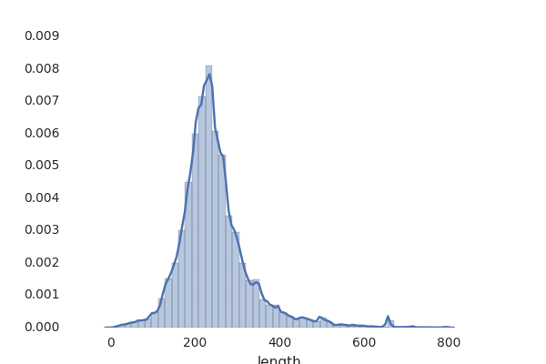

```python
"""
Displaying the distribution of events lenghts, we can see that most of them lie within the 200-300 seconds (3 and 4 minutes) range, what a typical song lies.
"""
fig, ax = plt.subplots(figsize=(6,4))
_lengthData = sparkify_data.toPandas()["length"]
_lengthData = _lengthData[_lengthData.isnull() == False]
_lengthData = _lengthData[_lengthData < 800]
g = sns.distplot(_lengthData)
plt.grid(True)
display(fig)
```

##### Bivariate and Univariate bulk plots:

In these plots we can have a wide overview of the correlation among several variables separating the dots for "churn" and "not churn" users.

Comments on the plots:

General comment: In this particular problem we can have false hypothesis that bias the result of the algorithm based on the timelines presented in the data. That is, users that abandon the service, are no longer creating logs for the platform so that all the metrics related to "time" may be counterindicative in production environment. In other words, when the algorithm predict churn probability of a user, it may get confused between new users and likely to abandon users if we train it with time-related features. We can see in the plots below that most of the users that abandon, present the lower usage rate of the total users. (We define usage as an intuitive metric based on how much activities or log rows they have in the platform).

There are some variables that are very reasonably linearly correlated. They are mainly the features that correspond to a time-related feature or time spent within the platform and number of events hit by the user. For example, a user who has played a larger number of songs is more likely to hit the thumbs down or help button.

- avg_days_between_session: We can see in the univariate distribution plot that most of the highest density of "churn" users have less days between sessions that "not churn" users. This may be a consequence of what has been stated in the general comment.
- thumbs_down vs. total_songs_played: This plot is interesting because we can differentiate a clear cluster of "churn" users who listen to a low amount of hours but they hit a high number of thumbs down. This is an obvious indicative that thumbs down is greatly correlated with attrition in the platform. It is also quite intuitive.

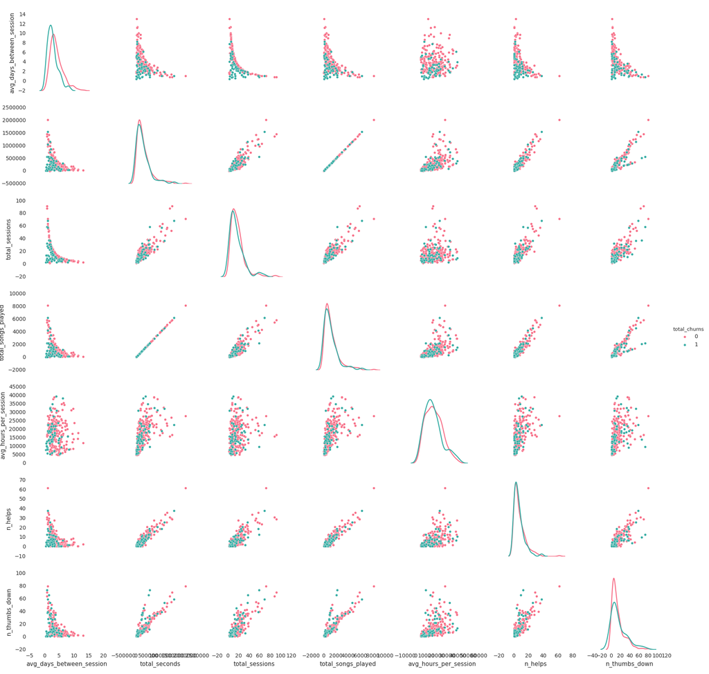

```python
g = sns.pairplot(dfFinal.select("avg_days_between_session", "total_seconds", "total_sessions","total_songs_played", "avg_hours_per_session", "n_helps", "total_churns", "n_thumbs_down").toPandas(), hue="total_churns", palette="husl", diag_kind="kde", vars=["avg_days_between_session", "total_seconds", "total_sessions", "total_songs_played", "avg_hours_per_session", "n_helps", "n_thumbs_down"])
display(g.fig)
```

To adequeate the data only to behavioural patterns of the users, we have used the scaled dataframe in which we have the divided all the time-related features by the time registered in the platform in hours, so now, we'll have the users actions as rates, for example, the songs played by hour, the thumbs down hit by hour, etc. We've isolated the dataframe from the time-related bias that will likely affect fresh new users in the platform. We'll sure that Sparkify won't want to offer discounts to users who are only about 1 week being using the service!

General Comment: We can see now that the data has condensed a bit more than before, it seems that we've lowered the effect of the time spent within the platform. Now we can see that the effect of the thumbs down feature is more informative. Most of the "churn" users have high values of thumbs down. It also seems, based on distribution plots that the highest density of "churn" users have used the platform a bit more intensely that "not churn" users, we can see that they have had more sessions per hour, more songs played per hour, etc.

There is also a kind of laziness among some users. If we take a look to the avg_days_between_session, we can see that users with longer periods among sessions (less interest in the platform) are the ones who do not abandon, it may seem that they are not paying much attention to Sparkify so thats why they don't cancel the service. Nevertheless, this group of users should also be a risky customer segment as they produce very low usage.

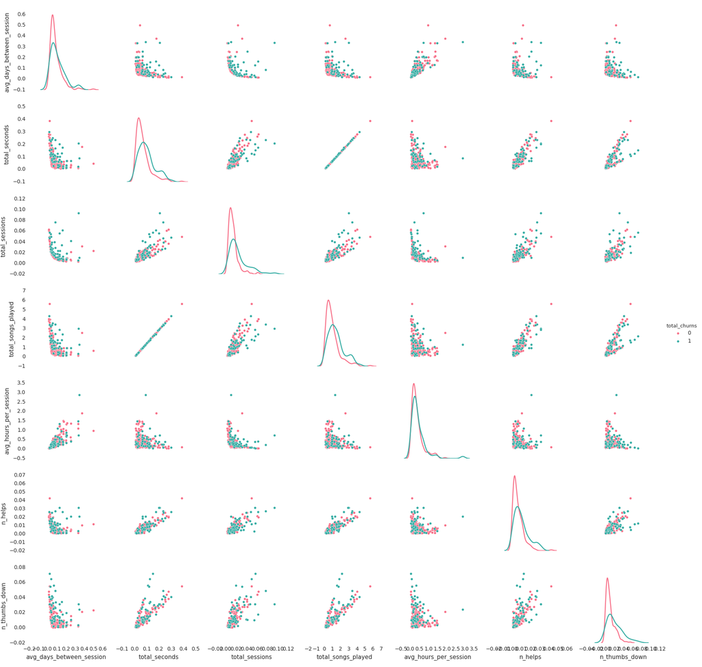

```python
g = sns.pairplot(dfFinalTimeScaled.select("avg_days_between_session", "total_seconds", "total_sessions","total_songs_played", "avg_hours_per_session", "n_helps", "total_churns", "n_thumbs_down").toPandas(), hue="total_churns", palette="husl", diag_kind="kde", vars=["avg_days_between_session", "total_seconds", "total_sessions", "total_songs_played", "avg_hours_per_session", "n_helps", "n_thumbs_down"])
display(g.fig)
```

### Data Preprocessing and Transformation:

As most of the data preprocessing steps have been performed before so that visualizations could be executed gracefully, let's normalize the data we have. Although we've already normalized some feature with regards to time spent in the platform, let's apply another normalizalization calculation so that the other features present in the dataframe don't contribute with a greater weight to the training process just because of the variability in scales.

We'll also convert the dataframe columns into Spark Dense Vectors. This is the required type for Models objects in Pyspark.

```python
from pyspark.ml.feature import VectorAssembler
assembler = VectorAssembler(
  inputCols=["total_seconds", "total_songs_played",
             "avg_hours_per_session", "n_free_items",
             "n_paid_items", "n_thumbs_down", "n_thumbs_up",
             "n_upgrades", "n_helps", "avg_days_between_session"],
  outputCol="features")

dfAssembled = assembler.transform(dfFinalTimeScaled)

from pyspark.ml.feature import Normalizer
normalizer = Normalizer(inputCol="features", outputCol="normFeatures", p=1.0)
dfScaled = normalizer.transform(dfAssembled)
```

```python
display(dfScaled.select("normFeatures").take(4))
```

| normFeatures |
| --- |
| List(1, 10, List(), List(0.014669699201177137, 0.2113711365869536, 0.4101265108607839, 0.12746809000281933, 0.1403762510157631, 0.004033800316544916, 0.020975761646033566, 0.0012101400949634748, 0.001… |
| List(1, 10, List(), List(0.027733821445562398, 0.40293050780096906, 0.04157827041432099, 0.08917760226634132, 0.3994866573069436, 0.005981424542254601, 0.021025613542470716, 7.250211566369214E-4, 0.00… |
| List(1, 10, List(), List(0.026716685781063777, 0.38848285923336817, 0.07174059237912124, 0.10593282599751594, 0.36598385194186034, 0.0029998676388677077, 0.021936532109220114, 5.624751822876951E-4, 0.… |
| List(1, 10, List(), List(0.027404685299089526, 0.39701311162861713, 0.05539254309506245, 0.10916746616050638, 0.3718377571875207, 0.0033418612089950936, 0.019828376506704222, 0.001559535230864377, 0.0… |

### Modelling and Tuning Performance:

Due to some limitations of memory in Databricks, we'll do the tuning "manually". The correct implementation of the performance tuning and besta parameters searching should have beend done by using a proper cross-validation with at least 5 folds and using a parameter grid finder.

```python
#dfModel = dfScaled.select("total_churns", "normFeatures").withColumnRenamed("normFeatures", "features").withColumnRenamed("total_churns", "label")
dfModel = dfAssembled.select("total_churns", "features").withColumnRenamed("features", "features").withColumnRenamed("total_churns", "label")
dfTrain, dfTest = dfModel.randomSplit([0.7, 0.3], 12)
```

```python
from pyspark.ml.classification import LogisticRegression
from sklearn.metrics import confusion_matrix, f1_score, classification_report

#from pyspark.ml.tuning import ParamGridBuilder, CrossValidator
#from pyspark.ml.evaluation import BinaryClassificationEvaluator

dfTrain = dfTrain.withColumn("weight", F.when(F.col("label") == 1, 2.5).otherwise(1.0))

"""Training the model"""
regParam=0.01
print("Logistic Regression with Regularization Parameter:" + str(regParam))
lr = LogisticRegression(maxIter=10, regParam=regParam)# weightCol="weight")
lrModel = lr.fit(dfTrain)

"""Test the model on test dataset"""
testLabels = lrModel.transform(dfTest)

"""Print metrics"""
ytrue = testLabels.select("label").toPandas()
ypred = testLabels.select("prediction").toPandas()
cm = confusion_matrix(ytrue, ypred)
print(cm)
print(classification_report(ytrue, ypred))
```

Logistic Regression with Regularization Parameter:0.01 [[53 2] [13 7]] precision recall f1-score support 0 0.80 0.96 0.88 55 1 0.78 0.35 0.48 20 avg / total 0.80 0.80 0.77 75

```python
from pyspark.ml.classification import LogisticRegression
from sklearn.metrics import confusion_matrix, f1_score, classification_report

#from pyspark.ml.tuning import ParamGridBuilder, CrossValidator
#from pyspark.ml.evaluation import BinaryClassificationEvaluator

dfTrain = dfTrain.withColumn("weight", F.when(F.col("label") == 1, 2.5).otherwise(1.0))

"""Training the model"""
regParam=0.1
print("Logistic Regression with Regularization Parameter:" + str(regParam))
lr = LogisticRegression(maxIter=10, regParam=regParam)# weightCol="weight")
lrModel = lr.fit(dfTrain)

"""Test the model on test dataset"""
testLabels = lrModel.transform(dfTest)

"""Print metrics"""
ytrue = testLabels.select("label").toPandas()
ypred = testLabels.select("prediction").toPandas()
cm = confusion_matrix(ytrue, ypred)
print(cm)
print(classification_report(ytrue, ypred))
```

Logistic Regression with Regularization Parameter:0.1 [[54 1] [13 7]] precision recall f1-score support 0 0.81 0.98 0.89 55 1 0.88 0.35 0.50 20 avg / total 0.82 0.81 0.78 75

```python
from pyspark.ml.classification import LogisticRegression
from sklearn.metrics import confusion_matrix, f1_score, classification_report

#from pyspark.ml.tuning import ParamGridBuilder, CrossValidator
#from pyspark.ml.evaluation import BinaryClassificationEvaluator

dfTrain = dfTrain.withColumn("weight", F.when(F.col("label") == 1, 3.0).otherwise(1.0))

"""Training the model"""
regParam=0.05
print("Logistic Regression with Regularization Parameter:" + str(regParam))
lr = LogisticRegression(maxIter=10, regParam=regParam)# weightCol="weight")
lrModel = lr.fit(dfTrain)

"""Test the model on test dataset"""
testLabels = lrModel.transform(dfTest)

"""Print metrics"""
ytrue = testLabels.select("label").toPandas()
ypred = testLabels.select("prediction").toPandas()
cm = confusion_matrix(ytrue, ypred)
print(cm)
print(classification_report(ytrue, ypred))
```

Logistic Regression with Regularization Parameter:0.05 [[54 1] [13 7]] precision recall f1-score support 0 0.81 0.98 0.89 55 1 0.88 0.35 0.50 20 avg / total 0.82 0.81 0.78 75

```python
from pyspark.ml.classification import GBTClassifier
from sklearn.metrics import confusion_matrix, f1_score, classification_report

#from pyspark.ml.tuning import ParamGridBuilder, CrossValidator
#from pyspark.ml.evaluation import BinaryClassificationEvaluator


"""Training the model"""
print("Logistic Regression with Regularization Parameter:" + str(regParam))
gbt = GBTClassifier(maxIter=10)# weightCol="weight")
gbtModel = gbt.fit(dfTrain)

"""Test the model on test dataset"""
testLabels = gbtModel.transform(dfTest)

"""Print metrics"""
ytrue = testLabels.select("label").toPandas()
ypred = testLabels.select("prediction").toPandas()
cm = confusion_matrix(ytrue, ypred)
print(cm)
print(classification_report(ytrue, ypred))
```

Logistic Regression with Regularization Parameter:0.05 [[52 3] [10 10]] precision recall f1-score support 0 0.84 0.95 0.89 55 1 0.77 0.50 0.61 20 avg / total 0.82 0.83 0.81 75

```python
from sklearn.metrics import confusion_matrix, f1_score, classification_report
print(cm)
print(classification_report(ytrue, ypred))
```

[output not shown]

```python
from pyspark.ml.classification import RandomForestClassifier
dt = RandomForestClassifier(labelCol="label", featuresCol="features", maxBins=15, minInstancesPerNode=3, numTrees=20)
treeModel = dt.fit(dfTrain)
testLabels = treeModel.transform(dfTest)
ytrue = testLabels.select("label").toPandas()
ypred = testLabels.select("prediction").toPandas()
cm = confusion_matrix(ytrue, ypred)
print(cm)
print(classification_report(ytrue, ypred))
```

[[54 1] [12 8]] precision recall f1-score support 0 0.82 0.98 0.89 55 1 0.89 0.40 0.55 20 avg / total 0.84 0.83 0.80 75

```python
from pyspark.ml.classification import GBTClassifier
from sklearn.metrics import confusion_matrix, f1_score, classification_report

#from pyspark.ml.tuning import ParamGridBuilder, CrossValidator
#from pyspark.ml.evaluation import BinaryClassificationEvaluator


"""Training the model"""
#print("Logistic Regression with Regularization Parameter:" + str(regParam))
gbt = GBTClassifier(maxIter=10, minInstancesPerNode=3, maxDepth=3)# weightCol="weight")
gbtModel = gbt.fit(dfTrain)

"""Test the model on test dataset"""
testLabels = gbtModel.transform(dfTest)

"""Print metrics"""
ytrue = testLabels.select("label").toPandas()
ypred = testLabels.select("prediction").toPandas()
cm = confusion_matrix(ytrue, ypred)
print(cm)
print(classification_report(ytrue, ypred))
```

[[54 1] [ 9 11]] precision recall f1-score support 0 0.86 0.98 0.92 55 1 0.92 0.55 0.69 20 avg / total 0.87 0.87 0.85 75

### Results:

```python
featuresImportances = gbtModel.featureImportances
featureColumns = ["total_seconds", "total_songs_played",
             "avg_hours_per_session", "n_free_items",
             "n_paid_items", "n_thumbs_down", "n_thumbs_up",
             "n_upgrades", "n_helps", "avg_days_between_session"]

featureImportancesWithColNames = {}
for i, col in enumerate(featureColumns):
   featureImportancesWithColNames[col] = featuresImportances[i]
```

### Model Information:

In this section we will try to explain a bit further some of the characteristics of the model chosen.

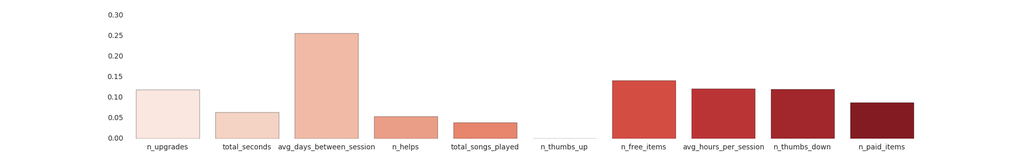

```python
fig, ax = plt.subplots(figsize=(20,3))
indices = [i for i, _ in enumerate(featureImportancesWithColNames.keys())]
g = sns.barplot(x=list(featureImportancesWithColNames.keys()), y =list(featureImportancesWithColNames.values()), orient="v", palette="Reds")
plt.xticks(rotation=0)
display(fig)
```

```python
numberOfTrees = gbtModel.getNumTrees
print("Number of Trees: {}".format(numberOfTrees))
treeWeights = gbtModel.treeWeights
print("Tree Weights: {}".format(treeWeights))
numberOfNodes = gbtModel.totalNumNodes
print("Tree Weights: {}".format(numberOfNodes))
```

Number of Trees: 10 Tree Weights: [1.0, 0.10000000000000001, 0.10000000000000001, 0.10000000000000001, 0.10000000000000001, 0.10000000000000001, 0.10000000000000001, 0.10000000000000001, 0.10000000000000001, 0.10000000000000001] Tree Weights: 146

We can check here that the model is composed of 10 decision trees, 1 of them has unit weigth and the other ones have 0.1 of weight contribution to the model.

### Justification:

The model selected has been a Gradient Boost Classifier. It has been demonstrated that performs better in the test set than the Logistic Regression and the Random Forest algorithm. GB is often good in problems related to anomaly detection where the dataset is unbalanced as it has been stated in several achademic studies. As it tries to correct the misclassifications during the optimization steps, it can find patterns very specific to those points, creating also a risk of overfitting. Another important point is that training time is a bit longer that its peers (almost 9 minutes with a relatively small dataset). Generally, Random Forest are a bit more robust models, but also they are more oriented to multiclass problems.

### Conclusion:

#### Reflection:

The problem has been partially solved for the dataset given. The model has acquired a decent percent of accuracy on detecting potential leavers. The study starts with an brief analysis of the dataset given, then, some initial visualizations are made to check some initial patterns in the data. As the data provided is hierarchied at the event log level, not much information could have been extracted without some basic transformations. Hence, several data wrangling steps are executed so that all the observations were comprised at the user level. As the model should classify if a user will abandon or not the service, it is a much more suitable schema to work on. After some visualizations the modelling is performed with several algorithms. Due to some limitations of computer power in "Databricks Community", high-memory demanding Spark jobs are likely to fail. Hence, the tuning step has been made "manually" within different jobs, and cross-validation was not possible to perform. Despite the fact these issues, a good model has been found.

#### Improvement:

The nature of the problem is quite interesting because the data given is based on event logs of current and already gone users. In addition, logs are obviously timelined. This fact makes the classification a bit sensible as the features that we create should not be based on the time that the user has spent subscribed within the platform. If this happens, we may come to the point where the model misclassifies new users based on their time-related features. This is a kind of "cold start" issue if we compare with recommendation engine problems. In production environment, the model should be applied only to users that have been in the platform a minimum amount of time. Regarding this fact, the features engineered should have had been based only on behavioural patterns. This engineering step has to be made along with different stakeholders within Sparkify that can throw some light on different attributes of the platform and the log events.

Another point to improve is the amount of data used for training. The dataset given seems to be huge but in the end it is giving information of no more than 400 users, what makes the model not very likely to generalize on a different sample. These dataset may not be representative of the whole platform activity.

The tuning and performance step of the analysis should also be conducted more formally, using the cross-validation object provided by Spark, which also allows to use its grid search class for hyperparameter tuning. This may have improved the model results on the test dataset with the optimal hyperparameters, which have a lot of influence in decision tree's based ensemble algorithms.